# MPA - UNIFEI

2021-11-29

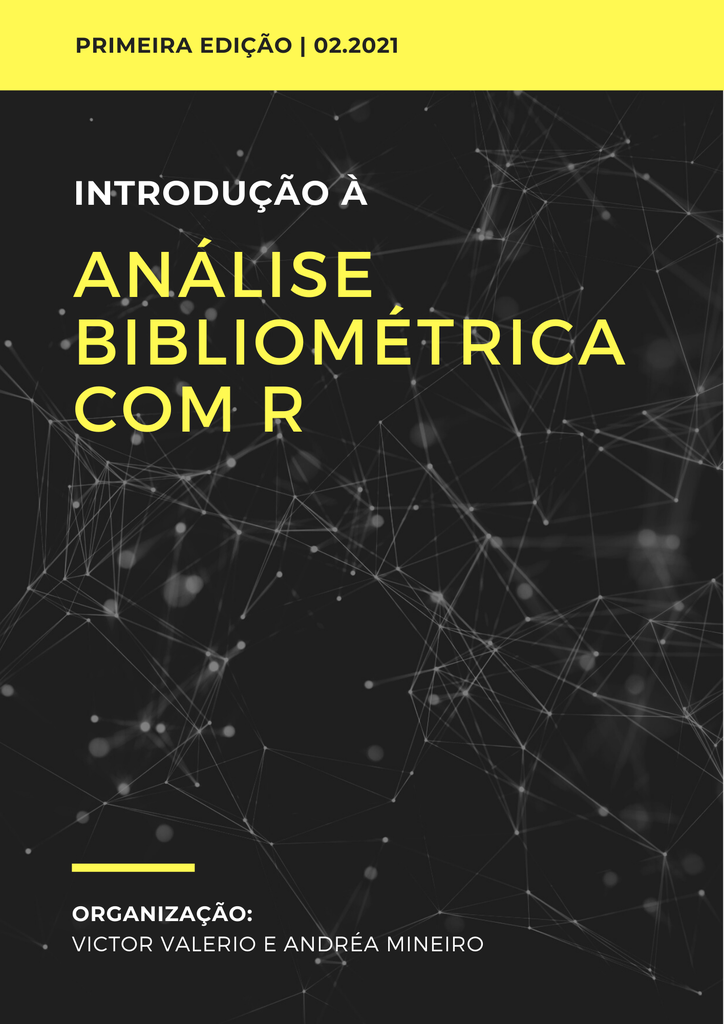

# SOBRE O CURSO

Define-se por análise bibliométrica um conjunto de procedimentos sistemáticos e rigorosos de exploração de um grande volume de metadados científicos trata-se, portanto, de uma das aplicações possíveis da área de Ciência de Dados. Você sabia que as publicações de artigos contendo análises bibliométricas estão crescendo de maneira acelerada em todo o mundo? Em números, tem-se uma média de crescimento anual de cerca de **30,65%** ao considerarmos, por exemplo, a base de dados Web of Science (WoS) entre os anos de 2010 a 2020. Este movimento pode ser observado no gif abaixo, organizado a partir de artigos publicados apenas em periódicos científicos e na língua inglesa.

[figure not shown]

Uma série de fatores associados podem explicar a referida tendência de crescimento das publicações. Por um lado, pode-se observar uma melhora das bases de metadados científicos (SCOPUS e WoS), de outro lado, uma série de softwares comerciais estão sendo desenvolvidos com a finalidade de implementar estas análises. Este cenário vem facilitando cada vez mais o acesso de pesquisador@s das mais diversas áreas e a utilização destes estudos por laboratórios de pesquisa, universidades, editor@s de periódicos e até mesmo governos.

Dentre os referidos softwares pode-se apontar como destaque o R, mais especificamente, o seu pacote de análise bibliométrica chamado [**bibliometrix**](https://www.bibliometrix.org/). Este pacote foi desenvolvido recentemente por Massimo Aria e Corrado Cuccurullo e, portanto, todo o seu potencial ainda não foi explorado pela literatura científica (para se ter uma boa noção do potencial do bibliometrix basta avaliar o [**artigo**](https://www.sciencedirect.com/science/article/pii/S1751157717300500) dos seus desenvolvedores publicado no *Journal of Informetrics*).

Por sua vez, é possível levantar uma série de fatores que corroboram ao entendimento de que a utilização da linguagem R para implementação de análises bibliométricas se destaca frente a outros softwares.

- **Para pesquisadores habituados à programação**
  - Linguagem criada e mantida por estatísticos, em um projeto *open-source*, com o fornecimento de uma ampla gama de ferramentas estatísticas (algoritmos já implementados!). Se existe uma técnica estatística, ela já foi implementada em R;
  - Comunidade ativa de pesquisadores debatendo avanços em diversos fóruns e, ao mesmo passo, auxiliando em implementações diversas de maneira colaborativa (de modo a integrar cientistas em todo o mundo);
  - Promoção de pesquisas reprodutíveis, abertas e acessíveis;
  - Abrange todas as etapas da ciência de dados (importação de dados, arrumação dos dados, transformação dos dados, visualização e modelagem dos dados, reportação e reprodução das análises). Por exemplo, esta página web do curso foi desenvolvida em linguagem R (módulo de reportação permite o desenvolvimento de documentos dinâmicos, blogs, sites, aplicativos).
- **Para pesquisadores não habituados à programação**
  - Linguagem acessível a não programadores;
  - O pacote bibliometrix possui uma interface gráfica de modo que todos possam calcular e analisar diversos indicadores bibliométricos sem ter que escrever uma linha sequer de programação.

## Objetivo do Curso

Assim, este curso foi criado visando “capturar” esta tendência de crescimento de publicações de análises bibliométricas a partir de uma das ferramentas mais poderosas (mais uma vez, o pacote bibliometrix do R). De maneira formal, o presente curso tem por objetivo geral realizar um treinamento em programação na linguagem R com foco na implementação de análises bibliométricas a partir do pacote Bibliometrix. O treinamento deverá ser realizado para discentes de programas de pós-graduação da UNIFEI e, também, de outras instituições.

Deste modo, o treinamento foi estruturado nas seguintes etapas:

- Guia de instalação do software R e da IDE RSTUDIO.
- Guia de instalação do pacote Bibliometrix.
- Guia de como pesquisar e exportar metadados de bases científicas (SCOPUS e Web of Science).
- Como carregar a aplicação web Biblioshiny do pacote Bibliometrix?
- Como importar os metadados para a aplicação web Biblioshiny do pacote Bibliometrix?
- Como calcular e interpretar indicadores bibliométricos a partir da aplicação web Biblioshiny?
- Introdução à relatórios bibliométricos reprodutíveis no R.

# INSCRIÇÕES

A finalidade última da análise bibliométrica não está no mapeamento científico *per se*, mas na divulgação científica, no acesso das pessoas, d@s pesquisador@s, de laboratórios, universidades, editoras, governos, à estruturação da visão científica sobre determinado tema. No mesmo sentido, o presente curso tem por finalidade última o **acesso** (seja bem vind@ ao engajamento da comunidade R).

Assim, nesta edição tod@s podem participar do curso! O treinamento será realizado em ambiente virtual (a partir da plataforma google meet) e de maneira síncrona. As datas e links são disponibilizadas abaixo:

- **Análise Bibliométrica com R - Parte I**
  - Terça-feira, 23 de novembro (21:00 até 22:30);
  - Link da videochamada: [**clique aqui**](https://meet.google.com/fjg-padb-yvn).
- **Análise Bibliométrica com R - Parte II**
  - Quinta-feira, 25 de novembro (19:00 até 21:00)
  - Link da videochamada: [**clique aqui**](https://meet.google.com/wqu-gjss-wpq).

Não há qualquer pré-requisito para participação do treinamento (você não precisa ter nenhuma familiaridade com a linguagem R), de fato, você apenas precisará ter um computador disponível e, obviamente, acesso à internet. Além disso, é relevante que você já tenha o R instalado antes do início do treinamento e, preferencialmente, também já tenha uma base de dados relacionada ao seu tema já preparada para análise.

Fique tranquil@ em relação a instalação do R e a preparação da base de dados, nós preparamos vídeos para vocês sobre o tema e eles serão disponibilizados na seção **ESTAÇÃO DE TRABALHO** deste documento. É importante ressaltar que estes vídeos serão disponibilizados no dia 22 de novembro (segunda-feira) para que você já chegue com tudo pronto para o primeiro dia de treinamento (fique atent@).

No entanto, é muito relevante realizar a inscrição para que possamos, nos comunicar, compreender a relevância do curso, aproximar à comunidade, ofertar outros treinamentos, enfim, para viabilizar a organização por parte da nossa equipe. Para tanto, basta preencher um rápido formulário (disponibilizado abaixo). Será assegurado um certificado de participação para tod@s os participantes inscrit@s.

- **COMUNIDADE UNIFEI (ESTUDANTES, SERVIDORES, DOCENTES)**:
  - Caso você faça parte da comunidade UNIFEI, acesse o formulário de inscrição [**CLICANDO AQUI**](https://forms.gle/LyuirCBywf7NeTTF6)!
- **COMUNIDADE EXTERNA**:
  - Caso você não faça parte da comunidade UNIFEI, faça o seu cadastro no SIGAA primeiro. Basta clicar em *“Ainda não possuo cadastro”* depois de [**CLICAR AQUI**](https://sigaa.unifei.edu.br/sigaa/public/extensao/loginCursosEventosExtensao.jsf) ,então, preencha os dados solicitados! Após cadastro no SIGAA, envie um e-mail para **victor.dmv@unifei.edu.br** avisando que você pretende participar do curso!

# ESTAÇÃO DE TRABALHO

Para preparar a nossa estação de trabalho são necessárias duas etapas. Em primeiro lugar, todos os softwares e pacotes necessários à implementação da análise bibliométrica deverão ser instalados. Em seguida, a base de dados, isto é, a amostra de metadados científicos deve ser adequadamente preparada de modo a viabilizar resultados consistentes. Assim, esta seção foi organizada com esta finalidade!

A etapa de instalação é bem simples, de fato, poucos passos são necessários. O vídeo explicando a instalação pode ser acessado [**CLICANDO AQUI**](https://youtu.be/qrkF-mao7pc)! Ao acompanhar o video você compreenderá como instalar o R, RStudio e, além disso, como instalar o pacote bibliometrix dentro da sessão do R. Os links comentados no vídeo são disponibilizados a seguir:

- Instalação do R: [**LINK**](https://cran-r.c3sl.ufpr.br/);
- Instalação do RStudio: [**LINK**](https://www.rstudio.com/products/rstudio/download/#download).

Por sua vez, se você se interessou pelo curso provavelmente está engajado de alguma maneira à atividade de pesquisa e, portanto, já está habituado a buscar artigos científicos que tratam do seu tema de interesse e que estão disponíveis nas melhores bases de dados (por exemplo, Web of Science e SCOPUS). De todo modo, é necessário compreender como preparar estes dados (ou melhor, metadados) de modo a viabilizar a implementação da análise bibliométrica. Neste sentido, o vídeo explicando como pesquisar, exportar e organizar os metadados científicos pode ser acesso [**CLICANDO AQUI**](https://youtu.be/zNnL8N8ZCCI)!

Em associação, o link para acesso ao portal da CAPES é disponibilizado a seguir:

- Portal da CAPES: [**LINK**](https://www-periodicos-capes-gov-br.ezl.periodicos.capes.gov.br/index.php?).

# AULAS

## PRIMEIRA APRESENTAÇÃO DO CURSO

- Para acessar o video da primeira apresentação basta [**CLICAR AQUI**](https://youtu.be/1vH-6jse1Ro).

## SEGUNDA APRESENTAÇÃO DO CURSO

- Para acessar o video da segunda apresentação basta [**CLICAR AQUI**](https://youtu.be/yPlfpJMUtR8).

## ACESSO AO APLICATIVO

Para acessar o aplicativo desenvolvido com a finalidade de agrupar os metadados científicos da SCOPUS e da Web of Science (WoS), basta [**CLICAR AQUI**](https://profvictorunifei.shinyapps.io/app_bibliometria/).